# Risk Factor Analysis

## Outcome Variable

**Outcome Variable:** pers_wast

## Predictor Variables

**Intervention Variable:** exclfeed3

**Adjustment Set:**

unadjusted

## Stratifying Variables

The analysis was stratified on these variable(s):

- agecat
- studyid
- country

## Data Summary

| agecat | studyid | country | exclfeed3 | pers_wast | n_cell | n |
| --- | --- | --- | --- | --- | --- | --- |
| 0-24 months | ki0047075b-MAL-ED | BANGLADESH | 1 | 0 | 169 | 244 |
| 0-24 months | ki0047075b-MAL-ED | BANGLADESH | 1 | 1 | 8 | 244 |
| 0-24 months | ki0047075b-MAL-ED | BANGLADESH | 0 | 0 | 63 | 244 |
| 0-24 months | ki0047075b-MAL-ED | BANGLADESH | 0 | 1 | 4 | 244 |
| 0-24 months | ki0047075b-MAL-ED | BRAZIL | 1 | 0 | 83 | 217 |
| 0-24 months | ki0047075b-MAL-ED | BRAZIL | 1 | 1 | 1 | 217 |
| 0-24 months | ki0047075b-MAL-ED | BRAZIL | 0 | 0 | 132 | 217 |
| 0-24 months | ki0047075b-MAL-ED | BRAZIL | 0 | 1 | 1 | 217 |
| 0-24 months | ki0047075b-MAL-ED | INDIA | 1 | 0 | 135 | 238 |
| 0-24 months | ki0047075b-MAL-ED | INDIA | 1 | 1 | 9 | 238 |
| 0-24 months | ki0047075b-MAL-ED | INDIA | 0 | 0 | 82 | 238 |
| 0-24 months | ki0047075b-MAL-ED | INDIA | 0 | 1 | 12 | 238 |
| 0-24 months | ki0047075b-MAL-ED | NEPAL | 1 | 0 | 84 | 235 |
| 0-24 months | ki0047075b-MAL-ED | NEPAL | 1 | 1 | 2 | 235 |
| 0-24 months | ki0047075b-MAL-ED | NEPAL | 0 | 0 | 147 | 235 |
| 0-24 months | ki0047075b-MAL-ED | NEPAL | 0 | 1 | 2 | 235 |
| 0-24 months | ki0047075b-MAL-ED | PERU | 1 | 0 | 68 | 281 |
| 0-24 months | ki0047075b-MAL-ED | PERU | 1 | 1 | 0 | 281 |
| 0-24 months | ki0047075b-MAL-ED | PERU | 0 | 0 | 212 | 281 |
| 0-24 months | ki0047075b-MAL-ED | PERU | 0 | 1 | 1 | 281 |
| 0-24 months | ki0047075b-MAL-ED | SOUTH AFRICA | 1 | 0 | 33 | 267 |
| 0-24 months | ki0047075b-MAL-ED | SOUTH AFRICA | 1 | 1 | 0 | 267 |
| 0-24 months | ki0047075b-MAL-ED | SOUTH AFRICA | 0 | 0 | 232 | 267 |
| 0-24 months | ki0047075b-MAL-ED | SOUTH AFRICA | 0 | 1 | 2 | 267 |
| 0-24 months | ki0047075b-MAL-ED | TANZANIA, UNITED REPUBLIC OF | 1 | 0 | 68 | 246 |
| 0-24 months | ki0047075b-MAL-ED | TANZANIA, UNITED REPUBLIC OF | 1 | 1 | 0 | 246 |
| 0-24 months | ki0047075b-MAL-ED | TANZANIA, UNITED REPUBLIC OF | 0 | 0 | 178 | 246 |
| 0-24 months | ki0047075b-MAL-ED | TANZANIA, UNITED REPUBLIC OF | 0 | 1 | 0 | 246 |
| 0-24 months | ki1000108-CMC-V-BCS-2002 | INDIA | 1 | 0 | 10 | 10 |
| 0-24 months | ki1000108-CMC-V-BCS-2002 | INDIA | 1 | 1 | 0 | 10 |

[output cut: 154 more lines]

The following strata were considered:

- agecat: 0-24 months, studyid: ki0047075b-MAL-ED, country: BANGLADESH
- agecat: 0-24 months, studyid: ki0047075b-MAL-ED, country: BRAZIL
- agecat: 0-24 months, studyid: ki0047075b-MAL-ED, country: INDIA
- agecat: 0-24 months, studyid: ki0047075b-MAL-ED, country: NEPAL
- agecat: 0-24 months, studyid: ki0047075b-MAL-ED, country: PERU
- agecat: 0-24 months, studyid: ki0047075b-MAL-ED, country: SOUTH AFRICA
- agecat: 0-24 months, studyid: ki0047075b-MAL-ED, country: TANZANIA, UNITED REPUBLIC OF
- agecat: 0-24 months, studyid: ki1000108-CMC-V-BCS-2002, country: INDIA
- agecat: 0-24 months, studyid: ki1000108-IRC, country: INDIA
- agecat: 0-24 months, studyid: ki1000109-EE, country: PAKISTAN
- agecat: 0-24 months, studyid: ki1000304b-SAS-CompFeed, country: INDIA
- agecat: 0-24 months, studyid: ki1017093b-PROVIDE, country: BANGLADESH
- agecat: 0-24 months, studyid: ki1101329-Keneba, country: GAMBIA
- agecat: 0-24 months, studyid: ki1113344-GMS-Nepal, country: NEPAL
- agecat: 0-24 months, studyid: kiGH5241-JiVitA-3, country: BANGLADESH
- agecat: 0-24 months, studyid: kiGH5241-JiVitA-4, country: BANGLADESH
- agecat: 0-6 months, studyid: ki0047075b-MAL-ED, country: BANGLADESH
- agecat: 0-6 months, studyid: ki0047075b-MAL-ED, country: BRAZIL
- agecat: 0-6 months, studyid: ki0047075b-MAL-ED, country: INDIA
- agecat: 0-6 months, studyid: ki0047075b-MAL-ED, country: NEPAL
- agecat: 0-6 months, studyid: ki0047075b-MAL-ED, country: PERU
- agecat: 0-6 months, studyid: ki0047075b-MAL-ED, country: SOUTH AFRICA
- agecat: 0-6 months, studyid: ki0047075b-MAL-ED, country: TANZANIA, UNITED REPUBLIC OF
- agecat: 0-6 months, studyid: ki1000108-CMC-V-BCS-2002, country: INDIA
- agecat: 0-6 months, studyid: ki1000108-IRC, country: INDIA
- agecat: 0-6 months, studyid: ki1000109-EE, country: PAKISTAN
- agecat: 0-6 months, studyid: ki1017093b-PROVIDE, country: BANGLADESH
- agecat: 0-6 months, studyid: ki1101329-Keneba, country: GAMBIA
- agecat: 0-6 months, studyid: ki1113344-GMS-Nepal, country: NEPAL
- agecat: 0-6 months, studyid: kiGH5241-JiVitA-3, country: BANGLADESH
- agecat: 6-24 months, studyid: ki0047075b-MAL-ED, country: BANGLADESH
- agecat: 6-24 months, studyid: ki0047075b-MAL-ED, country: BRAZIL
- agecat: 6-24 months, studyid: ki0047075b-MAL-ED, country: INDIA
- agecat: 6-24 months, studyid: ki0047075b-MAL-ED, country: NEPAL
- agecat: 6-24 months, studyid: ki0047075b-MAL-ED, country: PERU
- agecat: 6-24 months, studyid: ki0047075b-MAL-ED, country: SOUTH AFRICA
- agecat: 6-24 months, studyid: ki0047075b-MAL-ED, country: TANZANIA, UNITED REPUBLIC OF
- agecat: 6-24 months, studyid: ki1000108-CMC-V-BCS-2002, country: INDIA
- agecat: 6-24 months, studyid: ki1000108-IRC, country: INDIA
- agecat: 6-24 months, studyid: ki1000109-EE, country: PAKISTAN
- agecat: 6-24 months, studyid: ki1000304b-SAS-CompFeed, country: INDIA
- agecat: 6-24 months, studyid: ki1017093b-PROVIDE, country: BANGLADESH
- agecat: 6-24 months, studyid: ki1101329-Keneba, country: GAMBIA
- agecat: 6-24 months, studyid: ki1113344-GMS-Nepal, country: NEPAL
- agecat: 6-24 months, studyid: kiGH5241-JiVitA-3, country: BANGLADESH
- agecat: 6-24 months, studyid: kiGH5241-JiVitA-4, country: BANGLADESH

### Dropped Strata

Some strata were dropped due to rare outcomes:

- agecat: 0-24 months, studyid: ki0047075b-MAL-ED, country: BANGLADESH
- agecat: 0-24 months, studyid: ki0047075b-MAL-ED, country: BRAZIL
- agecat: 0-24 months, studyid: ki0047075b-MAL-ED, country: NEPAL
- agecat: 0-24 months, studyid: ki0047075b-MAL-ED, country: PERU
- agecat: 0-24 months, studyid: ki0047075b-MAL-ED, country: SOUTH AFRICA
- agecat: 0-24 months, studyid: ki0047075b-MAL-ED, country: TANZANIA, UNITED REPUBLIC OF
- agecat: 0-24 months, studyid: ki1000108-CMC-V-BCS-2002, country: INDIA
- agecat: 0-24 months, studyid: ki1000108-IRC, country: INDIA
- agecat: 0-24 months, studyid: ki1000304b-SAS-CompFeed, country: INDIA
- agecat: 0-24 months, studyid: kiGH5241-JiVitA-4, country: BANGLADESH
- agecat: 0-6 months, studyid: ki0047075b-MAL-ED, country: BANGLADESH
- agecat: 0-6 months, studyid: ki0047075b-MAL-ED, country: BRAZIL
- agecat: 0-6 months, studyid: ki0047075b-MAL-ED, country: NEPAL
- agecat: 0-6 months, studyid: ki0047075b-MAL-ED, country: PERU
- agecat: 0-6 months, studyid: ki0047075b-MAL-ED, country: SOUTH AFRICA
- agecat: 0-6 months, studyid: ki0047075b-MAL-ED, country: TANZANIA, UNITED REPUBLIC OF
- agecat: 0-6 months, studyid: ki1000108-CMC-V-BCS-2002, country: INDIA
- agecat: 0-6 months, studyid: ki1000108-IRC, country: INDIA
- agecat: 0-6 months, studyid: kiGH5241-JiVitA-3, country: BANGLADESH
- agecat: 6-24 months, studyid: ki0047075b-MAL-ED, country: BANGLADESH
- agecat: 6-24 months, studyid: ki0047075b-MAL-ED, country: BRAZIL
- agecat: 6-24 months, studyid: ki0047075b-MAL-ED, country: NEPAL
- agecat: 6-24 months, studyid: ki0047075b-MAL-ED, country: PERU
- agecat: 6-24 months, studyid: ki0047075b-MAL-ED, country: SOUTH AFRICA
- agecat: 6-24 months, studyid: ki0047075b-MAL-ED, country: TANZANIA, UNITED REPUBLIC OF
- agecat: 6-24 months, studyid: ki1000108-CMC-V-BCS-2002, country: INDIA
- agecat: 6-24 months, studyid: ki1000108-IRC, country: INDIA
- agecat: 6-24 months, studyid: ki1000304b-SAS-CompFeed, country: INDIA
- agecat: 6-24 months, studyid: kiGH5241-JiVitA-4, country: BANGLADESH

## Methods Detail

We’re interested in the causal parameters $E[Y_a]$ for all values of $a \in \mathcal{A}$. These parameters represent the mean outcome if, possibly contrary to fact, we intervened to set all units to have $A=a$. Under the randomization and positivity assumptions, these are identified by the statistical parameters $\psi_a=E_W[E_{Y|A,W}(Y|A=a,W)]$. In addition, we’re interested in the mean of $Y$, $E[Y]$ under no intervention (the observed mean). We will estimate these parameters by using SuperLearner to fit the relevant likelihood factors – $E_{Y|A,W}(Y|A=a,W)$ and $p(A=a|W)$, and then updating our likelihood fit using a joint TMLE.

For unadjusted analyses ($W=\{\}$), initial likelihoods were estimated using Lrnr_glm to estimate the simple $E(Y|A)$ and Lrnr_mean to estimate $p(A)$. For adjusted analyses, a small library containing Lrnr_glmnet, Lrnr_xgboost, and Lrnr_mean was used.

Having estimated these parameters, we will then use the delta method to estimate relative risks and attributable risks relative to a prespecified baseline level of $A$.

# Results Detail

## Results Plots

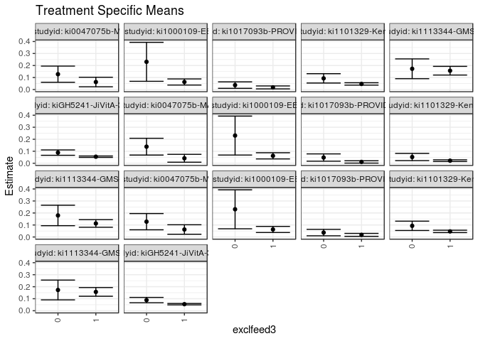

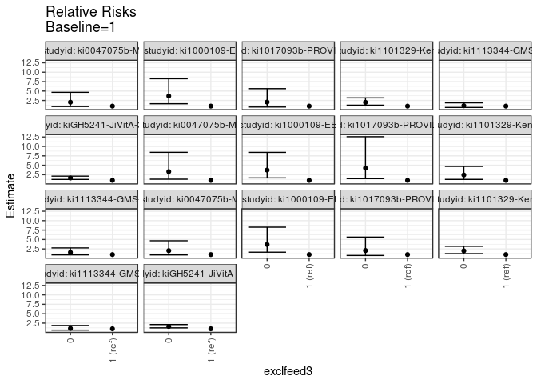

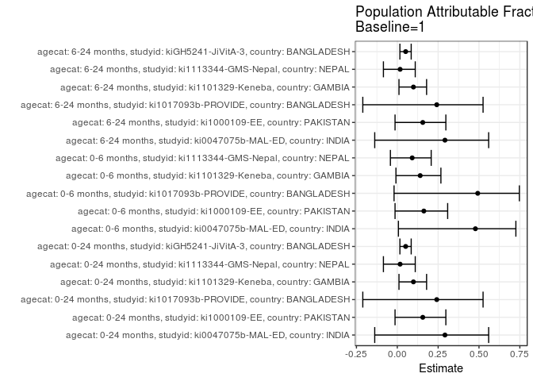

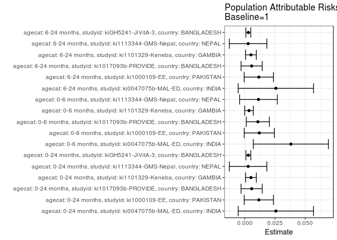

## Results Table

### Parameter: TSM

| agecat | studyid | country | intervention_level | baseline_level | estimate | ci_lower | ci_upper |
| --- | --- | --- | --- | --- | --- | --- | --- |
| 0-24 months | ki0047075b-MAL-ED | INDIA | 1 | NA | 0.0625000 | 0.0228807 | 0.1021193 |
| 0-24 months | ki0047075b-MAL-ED | INDIA | 0 | NA | 0.1276596 | 0.0600562 | 0.1952629 |
| 0-24 months | ki1000109-EE | PAKISTAN | 1 | NA | 0.0628571 | 0.0373963 | 0.0883180 |
| 0-24 months | ki1000109-EE | PAKISTAN | 0 | NA | 0.2307692 | 0.0686043 | 0.3929342 |
| 0-24 months | ki1017093b-PROVIDE | BANGLADESH | 1 | NA | 0.0177778 | 0.0055591 | 0.0299965 |
| 0-24 months | ki1017093b-PROVIDE | BANGLADESH | 0 | NA | 0.0368421 | 0.0100361 | 0.0636481 |
| 0-24 months | ki1101329-Keneba | GAMBIA | 1 | NA | 0.0466321 | 0.0367139 | 0.0565503 |
| 0-24 months | ki1101329-Keneba | GAMBIA | 0 | NA | 0.0930233 | 0.0541873 | 0.1318592 |
| 0-24 months | ki1113344-GMS-Nepal | NEPAL | 1 | NA | 0.1568123 | 0.1206390 | 0.1929856 |
| 0-24 months | ki1113344-GMS-Nepal | NEPAL | 0 | NA | 0.1728395 | 0.0904097 | 0.2552694 |
| 0-24 months | kiGH5241-JiVitA-3 | BANGLADESH | 1 | NA | 0.0547221 | 0.0488142 | 0.0606300 |
| 0-24 months | kiGH5241-JiVitA-3 | BANGLADESH | 0 | NA | 0.0887218 | 0.0663511 | 0.1110925 |
| 0-6 months | ki0047075b-MAL-ED | INDIA | 1 | NA | 0.0416667 | 0.0089602 | 0.0743732 |
| 0-6 months | ki0047075b-MAL-ED | INDIA | 0 | NA | 0.1382979 | 0.0683644 | 0.2082313 |
| 0-6 months | ki1000109-EE | PAKISTAN | 1 | NA | 0.0619469 | 0.0362508 | 0.0876430 |
| 0-6 months | ki1000109-EE | PAKISTAN | 0 | NA | 0.2307692 | 0.0685978 | 0.3929407 |
| 0-6 months | ki1017093b-PROVIDE | BANGLADESH | 1 | NA | 0.0111607 | 0.0014252 | 0.0208962 |
| 0-6 months | ki1017093b-PROVIDE | BANGLADESH | 0 | NA | 0.0476190 | 0.0172344 | 0.0780037 |
| 0-6 months | ki1101329-Keneba | GAMBIA | 1 | NA | 0.0215650 | 0.0144962 | 0.0286338 |
| 0-6 months | ki1101329-Keneba | GAMBIA | 0 | NA | 0.0521327 | 0.0221304 | 0.0821350 |
| 0-6 months | ki1113344-GMS-Nepal | NEPAL | 1 | NA | 0.1128609 | 0.0810536 | 0.1446682 |
| 0-6 months | ki1113344-GMS-Nepal | NEPAL | 0 | NA | 0.1794872 | 0.0942294 | 0.2647449 |
| 6-24 months | ki0047075b-MAL-ED | INDIA | 1 | NA | 0.0625000 | 0.0228807 | 0.1021193 |
| 6-24 months | ki0047075b-MAL-ED | INDIA | 0 | NA | 0.1276596 | 0.0600562 | 0.1952629 |
| 6-24 months | ki1000109-EE | PAKISTAN | 1 | NA | 0.0628571 | 0.0373963 | 0.0883180 |
| 6-24 months | ki1000109-EE | PAKISTAN | 0 | NA | 0.2307692 | 0.0686043 | 0.3929342 |
| 6-24 months | ki1017093b-PROVIDE | BANGLADESH | 1 | NA | 0.0177778 | 0.0055591 | 0.0299965 |
| 6-24 months | ki1017093b-PROVIDE | BANGLADESH | 0 | NA | 0.0368421 | 0.0100361 | 0.0636481 |
| 6-24 months | ki1101329-Keneba | GAMBIA | 1 | NA | 0.0466321 | 0.0367139 | 0.0565503 |
| 6-24 months | ki1101329-Keneba | GAMBIA | 0 | NA | 0.0930233 | 0.0541873 | 0.1318592 |
| 6-24 months | ki1113344-GMS-Nepal | NEPAL | 1 | NA | 0.1568123 | 0.1206390 | 0.1929856 |
| 6-24 months | ki1113344-GMS-Nepal | NEPAL | 0 | NA | 0.1728395 | 0.0904097 | 0.2552694 |
| 6-24 months | kiGH5241-JiVitA-3 | BANGLADESH | 1 | NA | 0.0547221 | 0.0488142 | 0.0606300 |
| 6-24 months | kiGH5241-JiVitA-3 | BANGLADESH | 0 | NA | 0.0887218 | 0.0663511 | 0.1110925 |

### Parameter: E(Y)

| agecat | studyid | country | intervention_level | baseline_level | estimate | ci_lower | ci_upper |
| --- | --- | --- | --- | --- | --- | --- | --- |
| 0-24 months | ki0047075b-MAL-ED | INDIA | NA | NA | 0.0882353 | 0.0521245 | 0.1243460 |
| 0-24 months | ki1000109-EE | PAKISTAN | NA | NA | 0.0744681 | 0.0478968 | 0.1010394 |
| 0-24 months | ki1017093b-PROVIDE | BANGLADESH | NA | NA | 0.0234375 | 0.0117074 | 0.0351676 |
| 0-24 months | ki1101329-Keneba | GAMBIA | NA | NA | 0.0517418 | 0.0419129 | 0.0615707 |
| 0-24 months | ki1113344-GMS-Nepal | NEPAL | NA | NA | 0.1595745 | 0.1264314 | 0.1927176 |
| 0-24 months | kiGH5241-JiVitA-3 | BANGLADESH | NA | NA | 0.0576722 | 0.0518186 | 0.0635258 |
| 0-6 months | ki0047075b-MAL-ED | INDIA | NA | NA | 0.0798319 | 0.0453258 | 0.1143380 |
| 0-6 months | ki1000109-EE | PAKISTAN | NA | NA | 0.0739726 | 0.0470855 | 0.1008598 |
| 0-6 months | ki1017093b-PROVIDE | BANGLADESH | NA | NA | 0.0219780 | 0.0105837 | 0.0333723 |
| 0-6 months | ki1101329-Keneba | GAMBIA | NA | NA | 0.0250818 | 0.0179232 | 0.0322404 |
| 0-6 months | ki1113344-GMS-Nepal | NEPAL | NA | NA | 0.1241830 | 0.0939798 | 0.1543862 |
| 6-24 months | ki0047075b-MAL-ED | INDIA | NA | NA | 0.0882353 | 0.0521245 | 0.1243460 |
| 6-24 months | ki1000109-EE | PAKISTAN | NA | NA | 0.0744681 | 0.0478968 | 0.1010394 |
| 6-24 months | ki1017093b-PROVIDE | BANGLADESH | NA | NA | 0.0234375 | 0.0117074 | 0.0351676 |
| 6-24 months | ki1101329-Keneba | GAMBIA | NA | NA | 0.0517418 | 0.0419129 | 0.0615707 |
| 6-24 months | ki1113344-GMS-Nepal | NEPAL | NA | NA | 0.1595745 | 0.1264314 | 0.1927176 |
| 6-24 months | kiGH5241-JiVitA-3 | BANGLADESH | NA | NA | 0.0576722 | 0.0518186 | 0.0635258 |

### Parameter: RR

| agecat | studyid | country | intervention_level | baseline_level | estimate | ci_lower | ci_upper |
| --- | --- | --- | --- | --- | --- | --- | --- |
| 0-24 months | ki0047075b-MAL-ED | INDIA | 1 | 1 | 1.000000 | 1.0000000 | 1.000000 |
| 0-24 months | ki0047075b-MAL-ED | INDIA | 0 | 1 | 2.042553 | 0.8942249 | 4.665519 |
| 0-24 months | ki1000109-EE | PAKISTAN | 1 | 1 | 1.000000 | 1.0000000 | 1.000000 |
| 0-24 months | ki1000109-EE | PAKISTAN | 0 | 1 | 3.671329 | 1.6314273 | 8.261879 |
| 0-24 months | ki1017093b-PROVIDE | BANGLADESH | 1 | 1 | 1.000000 | 1.0000000 | 1.000000 |
| 0-24 months | ki1017093b-PROVIDE | BANGLADESH | 0 | 1 | 2.072368 | 0.7617066 | 5.638274 |
| 0-24 months | ki1101329-Keneba | GAMBIA | 1 | 1 | 1.000000 | 1.0000000 | 1.000000 |
| 0-24 months | ki1101329-Keneba | GAMBIA | 0 | 1 | 1.994832 | 1.2485931 | 3.187071 |
| 0-24 months | ki1113344-GMS-Nepal | NEPAL | 1 | 1 | 1.000000 | 1.0000000 | 1.000000 |
| 0-24 months | ki1113344-GMS-Nepal | NEPAL | 0 | 1 | 1.102206 | 0.6489102 | 1.872151 |
| 0-24 months | kiGH5241-JiVitA-3 | BANGLADESH | 1 | 1 | 1.000000 | 1.0000000 | 1.000000 |
| 0-24 months | kiGH5241-JiVitA-3 | BANGLADESH | 0 | 1 | 1.621316 | 1.2399088 | 2.120047 |
| 0-6 months | ki0047075b-MAL-ED | INDIA | 1 | 1 | 1.000000 | 1.0000000 | 1.000000 |
| 0-6 months | ki0047075b-MAL-ED | INDIA | 0 | 1 | 3.319149 | 1.3047012 | 8.443886 |
| 0-6 months | ki1000109-EE | PAKISTAN | 1 | 1 | 1.000000 | 1.0000000 | 1.000000 |
| 0-6 months | ki1000109-EE | PAKISTAN | 0 | 1 | 3.725275 | 1.6472464 | 8.424770 |
| 0-6 months | ki1017093b-PROVIDE | BANGLADESH | 1 | 1 | 1.000000 | 1.0000000 | 1.000000 |
| 0-6 months | ki1017093b-PROVIDE | BANGLADESH | 0 | 1 | 4.266667 | 1.4478320 | 12.573589 |
| 0-6 months | ki1101329-Keneba | GAMBIA | 1 | 1 | 1.000000 | 1.0000000 | 1.000000 |
| 0-6 months | ki1101329-Keneba | GAMBIA | 0 | 1 | 2.417468 | 1.2465967 | 4.688084 |
| 0-6 months | ki1113344-GMS-Nepal | NEPAL | 1 | 1 | 1.000000 | 1.0000000 | 1.000000 |
| 0-6 months | ki1113344-GMS-Nepal | NEPAL | 0 | 1 | 1.590340 | 0.9154189 | 2.762867 |
| 6-24 months | ki0047075b-MAL-ED | INDIA | 1 | 1 | 1.000000 | 1.0000000 | 1.000000 |
| 6-24 months | ki0047075b-MAL-ED | INDIA | 0 | 1 | 2.042553 | 0.8942249 | 4.665519 |
| 6-24 months | ki1000109-EE | PAKISTAN | 1 | 1 | 1.000000 | 1.0000000 | 1.000000 |
| 6-24 months | ki1000109-EE | PAKISTAN | 0 | 1 | 3.671329 | 1.6314273 | 8.261879 |
| 6-24 months | ki1017093b-PROVIDE | BANGLADESH | 1 | 1 | 1.000000 | 1.0000000 | 1.000000 |
| 6-24 months | ki1017093b-PROVIDE | BANGLADESH | 0 | 1 | 2.072368 | 0.7617066 | 5.638274 |
| 6-24 months | ki1101329-Keneba | GAMBIA | 1 | 1 | 1.000000 | 1.0000000 | 1.000000 |
| 6-24 months | ki1101329-Keneba | GAMBIA | 0 | 1 | 1.994832 | 1.2485931 | 3.187071 |
| 6-24 months | ki1113344-GMS-Nepal | NEPAL | 1 | 1 | 1.000000 | 1.0000000 | 1.000000 |
| 6-24 months | ki1113344-GMS-Nepal | NEPAL | 0 | 1 | 1.102206 | 0.6489102 | 1.872151 |
| 6-24 months | kiGH5241-JiVitA-3 | BANGLADESH | 1 | 1 | 1.000000 | 1.0000000 | 1.000000 |
| 6-24 months | kiGH5241-JiVitA-3 | BANGLADESH | 0 | 1 | 1.621316 | 1.2399088 | 2.120047 |

### Parameter: PAR

| agecat | studyid | country | intervention_level | baseline_level | estimate | ci_lower | ci_upper |
| --- | --- | --- | --- | --- | --- | --- | --- |
| 0-24 months | ki0047075b-MAL-ED | INDIA | 1 | NA | 0.0257353 | -0.0054772 | 0.0569478 |
| 0-24 months | ki1000109-EE | PAKISTAN | 1 | NA | 0.0116109 | -0.0005313 | 0.0237532 |
| 0-24 months | ki1017093b-PROVIDE | BANGLADESH | 1 | NA | 0.0056597 | -0.0031121 | 0.0144315 |
| 0-24 months | ki1101329-Keneba | GAMBIA | 1 | NA | 0.0051097 | 0.0006481 | 0.0095713 |
| 0-24 months | ki1113344-GMS-Nepal | NEPAL | 1 | NA | 0.0027621 | -0.0127612 | 0.0182855 |
| 0-24 months | kiGH5241-JiVitA-3 | BANGLADESH | 1 | NA | 0.0029501 | 0.0009355 | 0.0049648 |
| 0-6 months | ki0047075b-MAL-ED | INDIA | 1 | NA | 0.0381653 | 0.0070857 | 0.0692449 |
| 0-6 months | ki1000109-EE | PAKISTAN | 1 | NA | 0.0120257 | -0.0004922 | 0.0245436 |
| 0-6 months | ki1017093b-PROVIDE | BANGLADESH | 1 | NA | 0.0108173 | 0.0012626 | 0.0203721 |
| 0-6 months | ki1101329-Keneba | GAMBIA | 1 | NA | 0.0035168 | -0.0000575 | 0.0070910 |
| 0-6 months | ki1113344-GMS-Nepal | NEPAL | 1 | NA | 0.0113221 | -0.0043104 | 0.0269547 |
| 6-24 months | ki0047075b-MAL-ED | INDIA | 1 | NA | 0.0257353 | -0.0054772 | 0.0569478 |
| 6-24 months | ki1000109-EE | PAKISTAN | 1 | NA | 0.0116109 | -0.0005313 | 0.0237532 |
| 6-24 months | ki1017093b-PROVIDE | BANGLADESH | 1 | NA | 0.0056597 | -0.0031121 | 0.0144315 |
| 6-24 months | ki1101329-Keneba | GAMBIA | 1 | NA | 0.0051097 | 0.0006481 | 0.0095713 |
| 6-24 months | ki1113344-GMS-Nepal | NEPAL | 1 | NA | 0.0027621 | -0.0127612 | 0.0182855 |
| 6-24 months | kiGH5241-JiVitA-3 | BANGLADESH | 1 | NA | 0.0029501 | 0.0009355 | 0.0049648 |

### Parameter: PAF

| agecat | studyid | country | intervention_level | baseline_level | estimate | ci_lower | ci_upper |
| --- | --- | --- | --- | --- | --- | --- | --- |
| 0-24 months | ki0047075b-MAL-ED | INDIA | 1 | NA | 0.2916667 | -0.1381351 | 0.5591594 |
| 0-24 months | ki1000109-EE | PAKISTAN | 1 | NA | 0.1559184 | -0.0137852 | 0.2972143 |
| 0-24 months | ki1017093b-PROVIDE | BANGLADESH | 1 | NA | 0.2414815 | -0.2111617 | 0.5249599 |
| 0-24 months | ki1101329-Keneba | GAMBIA | 1 | NA | 0.0987534 | 0.0103099 | 0.1792932 |
| 0-24 months | ki1113344-GMS-Nepal | NEPAL | 1 | NA | 0.0173093 | -0.0849023 | 0.1098913 |
| 0-24 months | kiGH5241-JiVitA-3 | BANGLADESH | 1 | NA | 0.0511534 | 0.0159526 | 0.0850950 |
| 0-6 months | ki0047075b-MAL-ED | INDIA | 1 | NA | 0.4780701 | 0.0069012 | 0.7256962 |
| 0-6 months | ki1000109-EE | PAKISTAN | 1 | NA | 0.1625696 | -0.0137823 | 0.3082444 |
| 0-6 months | ki1017093b-PROVIDE | BANGLADESH | 1 | NA | 0.4921875 | -0.0198203 | 0.7471383 |
| 0-6 months | ki1101329-Keneba | GAMBIA | 1 | NA | 0.1402127 | -0.0083386 | 0.2668790 |
| 0-6 months | ki1113344-GMS-Nepal | NEPAL | 1 | NA | 0.0911728 | -0.0421720 | 0.2074563 |
| 6-24 months | ki0047075b-MAL-ED | INDIA | 1 | NA | 0.2916667 | -0.1381351 | 0.5591594 |
| 6-24 months | ki1000109-EE | PAKISTAN | 1 | NA | 0.1559184 | -0.0137852 | 0.2972143 |
| 6-24 months | ki1017093b-PROVIDE | BANGLADESH | 1 | NA | 0.2414815 | -0.2111617 | 0.5249599 |
| 6-24 months | ki1101329-Keneba | GAMBIA | 1 | NA | 0.0987534 | 0.0103099 | 0.1792932 |
| 6-24 months | ki1113344-GMS-Nepal | NEPAL | 1 | NA | 0.0173093 | -0.0849023 | 0.1098913 |
| 6-24 months | kiGH5241-JiVitA-3 | BANGLADESH | 1 | NA | 0.0511534 | 0.0159526 | 0.0850950 |